# Intro to Data Science (Non-Technical Background, R) - Session06

Pipes are **ideal** to chain data transformations in R!

Now, the boxplot with {ggplot2}:

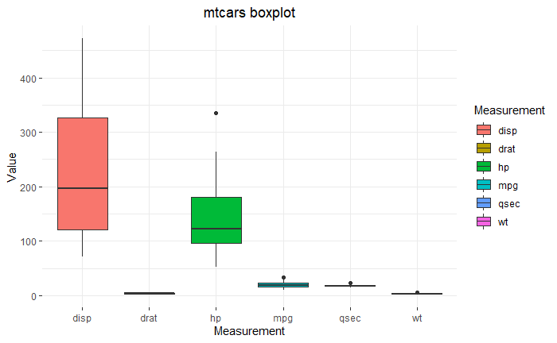

```r
ggplot(data = mtcarsPlot,
       aes(x = Measurement,
           y = Value,
           fill = Measurement)) +
  geom_boxplot() +
  ggtitle("mtcars boxplot") +
  theme_bw() +
  theme(panel.border = element_blank()) +
  theme(plot.title = element_text(hjust = .5))
```

**Note.** We use `+` to chain the layers in {ggplot2} visualizations, similarly as we use the pipes to chain data transformations. Do not confuse `+` as used to build a {ggplot2} visualization with `+` as an arithmetic operation or `%>%`.

We will play with various transformations of this boxplot in our session to learn about the basics of the fantastic, powerful {ggplot2} package! For example, let’s produce a **scatterplot** - another very important visualization in statistics and analytics to learn about - of two variables from `mtcars` with {ggplot2}, just to see how easy it is:

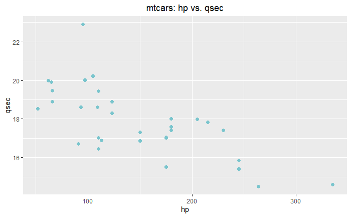

```r
ggplot(data = mtcars,
       aes(x = hp,
           y = qsec)) +
  geom_point(size = 2, color = "cadetblue3") +
  ggtitle("mtcars: hp vs. qsec") +
  theme(panel.border = element_blank()) +
  theme(plot.title = element_text(hjust = .5))
```

**Hypothesis.** There is a negative linear relationship between `mtcars$hp` and `mtcars$qsec`. Let’s see:

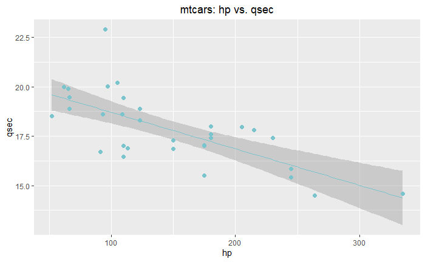

```r
ggplot(data = mtcars,
       aes(x = hp,
           y = qsec)) +
  geom_smooth(method = "lm", size = .25, color = "cadetblue3") +
  geom_point(size = 2, color = "cadetblue3") +
  ggtitle("mtcars: hp vs. qsec") +
  theme(panel.border = element_blank()) +
  theme(plot.title = element_text(hjust = .5))
```

Can our hypothesis be falsified? We will see in the remainder of the course. Now back to the EDA things! Before that, just another {ggplot2} trick to help you understand your data better…

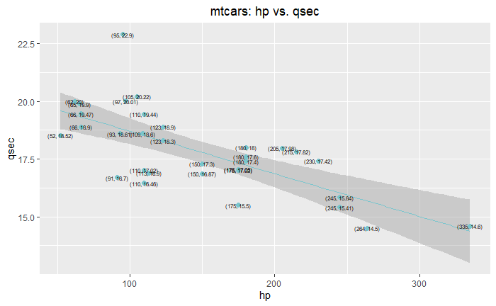

```r
mtcarsPlot <- mtcars %>%
  select(hp, qsec)
mtcarsPlot$label <- paste0("(",
                           mtcarsPlot$hp, ", ",
                           mtcarsPlot$qsec,
                           ")")
ggplot(data = mtcarsPlot,
       aes(x = hp,
           y = qsec,
           label = label)) +
  geom_smooth(method = "lm", size = .25, color = "cadetblue3") +
  geom_point(size = 2, color = "cadetblue3") +
  geom_text(size = 2) +
  ggtitle("mtcars: hp vs. qsec") +
  theme(panel.border = element_blank()) +
  theme(plot.title = element_text(hjust = .5))
```

Not readable enough? `install.packages(ggrepel)`. Now,

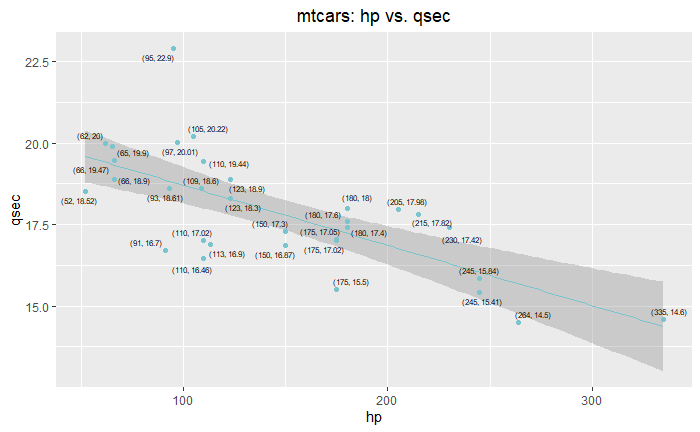

```r
library(ggrepel)
mtcarsPlot <- mtcars %>%
  select(hp, qsec)
mtcarsPlot$label <- paste0("(",
                           mtcarsPlot$hp, ", ",
                           mtcarsPlot$qsec,
                           ")")
ggplot(data = mtcarsPlot,
       aes(x = hp,
           y = qsec,
           label = label)) +
  geom_smooth(method = "lm", size = .25, color = "cadetblue3") +
  geom_point(size = 1.5, color = "cadetblue3") +
  geom_text_repel(size = 2) +
  ggtitle("mtcars: hp vs. qsec") +
  theme(panel.border = element_blank()) +
  theme(plot.title = element_text(hjust = .5))
```

### 2. Distributions and histograms

**Q.** How is the number of cylinders - `mtcars$cyl` - distributed across the models in the dataset?

```r
mtcarsPlot <- mtcars %>%
  select(cyl) %>%
  group_by(cyl) %>%
  summarise(count = n())
mtcarsPlot
```

| cyl | count |
| --- | --- |
| 4 | 11 |
| 6 | 7 |
| 8 | 14 |

I have used `dplyr::select()` to single out only the `cyl` variable, then *grouped* the data with `dplyr::group_by` to be able to aggregate across the distinct values in `cyl`, and finally used `dplyr::summarise()` to compute a new variable, `count`, in `mtcarsPlot`, by the `dplyr::n()` function which simply counts the number of elements in each group following `dplyr::group_by`. The chart:

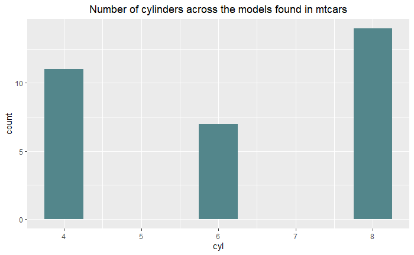

```r
ggplot(data = mtcarsPlot,
       aes(x = cyl,
           y = count)) +
  geom_bar(stat = "identity", fill = "cadetblue4", width = .5) +
  ggtitle("Number of cylinders across the models found in mtcars") +
  theme(panel.border = element_blank()) +
  theme(plot.title = element_text(hjust = .5))
```

How about the distribution of continuous variables? Remember our Exercises in Session03?

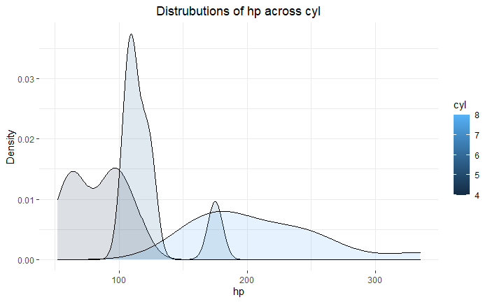

```r
ggplot(mtcars,
       aes(x = hp,
           fill = cyl,
           group = cyl)) +
  geom_density(alpha = .15, color = "black") +
  ggtitle("Distrubutions of hp across cyl") +
  xlab('hp') +
  ylab('Density') +
  theme_bw() +
  theme(panel.border = element_blank()) +
  theme(plot.title = element_text(hjust = .5))
```

Fine, but… `mtcars$cyl` needs to become an R **factor** first!

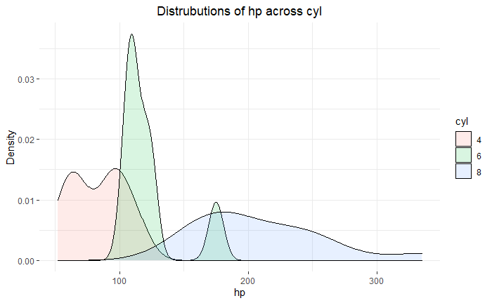

```r
mtcars$cyl <- as.factor(mtcars$cyl)
ggplot(mtcars,
       aes(x = hp,
           fill = cyl,
           group = cyl)) +
  geom_density(alpha = .15, color = "black") +
  ggtitle("Distrubutions of hp across cyl") +
  xlab('hp') +
  ylab('Density') +
  theme_bw() +
  theme(panel.border = element_blank()) +
  theme(plot.title = element_text(hjust = .5))
```

The overall distribution of `mtcars$hp` is:

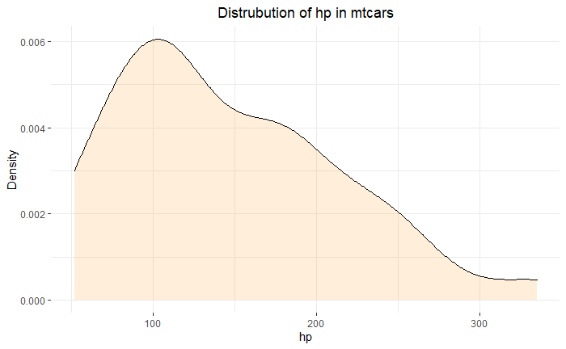

```r
ggplot(mtcars,
       aes(x = hp)) +
  geom_density(alpha = .15, color = "black", fill = "darkorange") +
  ggtitle("Distrubution of hp in mtcars") +
  xlab('hp') +
  ylab('Density') +
  theme_bw() +
  theme(panel.border = element_blank()) +
  theme(plot.title = element_text(hjust = .5))
```

### 3. Cross-Tabulations and Aggregations

**Q.** How is the average `qsec` distributed across `cyl` and `gear` in `mtcars`? Remember `table()`:

```r
distribution <-
  mtcars %>%
  select(cyl, gear, qsec) %>%
  group_by(cyl, gear) %>%
  summarise(meanQsec = mean(qsec))
print(distribution)
```

| cyl | gear | meanQsec |
| --- | --- | --- |
| 4 | 3 | 20.0100 |
| 4 | 4 | 19.6125 |
| 4 | 5 | 16.8000 |
| 6 | 3 | 19.8300 |
| 6 | 4 | 17.6700 |
| 6 | 5 | 15.5000 |
| 8 | 3 | 17.1425 |
| 8 | 5 | 14.5500 |

Now, one of my favorite {ggplot2} tricks to visualize a dataset like this one:

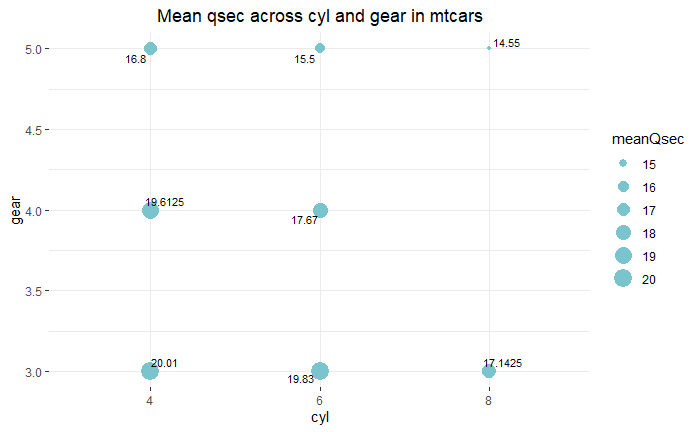

```r
ggplot(distribution,
       aes(x = cyl,
           y = gear,
           size = meanQsec,
           label = meanQsec)) +
  geom_point(color = "cadetblue3") +
  ggtitle("Mean qsec across cyl and gear in mtcars") +
  geom_text_repel(size = 3) +
  theme_bw() +
  theme(panel.border = element_blank()) +
  theme(plot.title = element_text(hjust = .5))
```

Or you can use `facet_warp()` in {ggplot2}:

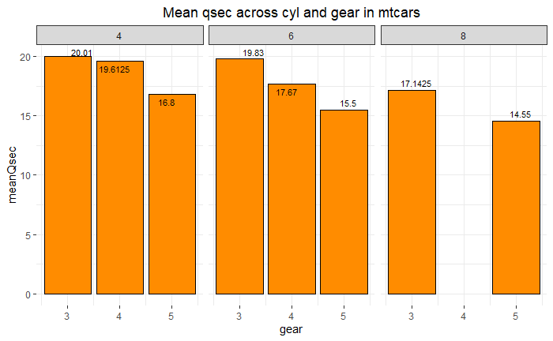

```r
ggplot(distribution,
       aes(x = gear,
           y = meanQsec,
           label = meanQsec)) +
  geom_bar(stat = "identity",
           color = "black",
           fill = "darkorange") +
  facet_wrap(~cyl) +
  ggtitle("Mean qsec across cyl and gear in mtcars") +
  geom_text_repel(size = 3) +
  theme_bw() +
  theme(panel.border = element_blank()) +
  theme(plot.title = element_text(hjust = .5))
```

### Further Readings

- [Chapter 7, Exploratory Data Analysis, from from R for Data Science, Hadley Wickham & Garrett Grolemund](https://r4ds.had.co.nz/exploratory-data-analysis.html)
- Everything from [Chapter 7, Exploratory Data Analysis, from from R for Data Science, Hadley Wickham & Garrett Grolemund](https://r4ds.had.co.nz) on {ggplot2}.

### R Markdown

[R Markdown](https://rmarkdown.rstudio.com/) is what I have used to produce this beautiful Notebook. We will learn more about it near the end of the course, but if you already feel ready to dive deep, here’s a book: [R Markdown: The Definitive Guide, Yihui Xie, J. J. Allaire, Garrett Grolemunds.](https://bookdown.org/yihui/rmarkdown/)

Goran S. Milovanović

DataKolektiv, 2020/21

contact: goran.milovanovic@datakolektiv.com

License: [GPLv3](http://www.gnu.org/licenses/gpl-3.0.txt) This Notebook is free software: you can redistribute it and/or modify it under the terms of the GNU General Public License as published by the Free Software Foundation, either version 3 of the License, or (at your option) any later version. This Notebook is distributed in the hope that it will be useful, but WITHOUT ANY WARRANTY; without even the implied warranty of MERCHANTABILITY or FITNESS FOR A PARTICULAR PURPOSE. See the GNU General Public License for more details. You should have received a copy of the GNU General Public License along with this Notebook. If not, see http://www.gnu.org/licenses/.